# week 2

Chong Zhang

January 18, 2018

## loading all the data and libraries

```r
cc_info = read.csv('credit_card_data-headers.txt', sep = '')
library(kernlab)
library(kknn)
library(ggplot2)
library(dplyr)
```

# Question 3.1

## 3.1.a

## Cross-validation

```r
set.seed(6)
# randomize the order of the original data
cc_info_random = cc_info[sample(nrow(cc_info)),]

# random sample 30% from the whole data to be used as test data
test_index = as.numeric(sample(row.names(cc_info_random), 0.3*nrow(cc_info)))
test = cc_info_random[test_index,]

# rest 80% are assigned for training and validation
train_validation = cc_info_random[-test_index,]

# k is set to 10.
k =10
# generate the index for 10 folds
k_fold <- cut(seq(1,nrow(train_validation)),breaks=10,labels=FALSE)

accuracy_per_k_knn = c()

for (n in 1:20){ # test different k value in KNN model
  accuracy_per_k_fold = c()
  for (i in 1:k){ # iterate through different k in f-fold
    index = which(k_fold == i, arr.ind = TRUE) #change the index into row numbers
    validation = train_validation[index,]
    training = train_validation[-index,]
    knn = kknn(formula = R1~., train = training, test = validation[,-11], k = n, scale = TRUE)

    # calculate accuracy for specific k
    accuracy = sum(round(knn$fitted.values) == validation[,11])/nrow(validation)
    # store the accuracy of each k fold
    accuracy_per_k_fold = c(accuracy_per_k_fold, accuracy)
  }
  # calculate the average accuracy for that specific k value in KNN model
  ave_accuracy_per_f_fold = mean(accuracy_per_k_fold)
  accuracy_per_k_knn = c(accuracy_per_k_knn,ave_accuracy_per_f_fold)
}
k_knn_accuracy = cbind('k' = 1:20, 'accuracy' = accuracy_per_k_knn)
print (k_knn_accuracy)
```

```
##        k  accuracy
##  [1,]  1 0.7814493
##  [2,]  2 0.7814493
##  [3,]  3 0.7814493
##  [4,]  4 0.7814493
##  [5,]  5 0.8185990
##  [6,]  6 0.8295652
##  [7,]  7 0.8252174
##  [8,]  8 0.8273430
##  [9,]  9 0.8317874
## [10,] 10 0.8361353
## [11,] 11 0.8361353
## [12,] 12 0.8361353
## [13,] 13 0.8317874
## [14,] 14 0.8317874
## [15,] 15 0.8296135
## [16,] 16 0.8252657
## [17,] 17 0.8253140
## [18,] 18 0.8231401
## [19,] 19 0.8275362
## [20,] 20 0.8275362
```

Based on all the k tested and cross-validation, the best k should be either **10**,**11** or **12**, which yeild an accuracy around **`0.836`**. Thus I decided to choose **12** to reconstruct the KNN model.

```r
# train the model with all the train_validattion data, and then predict the test data.
knn = kknn(formula = R1~.,train = train_validation, test = test[,-11], k = 12,scale = TRUE)
accuracy = sum(round(knn$fitted.values) == test[,11])/nrow(test)
print (accuracy)
```

```
## [1] 0.8673469
```

By setting the k value to **12**, i get an accuracy around**`0.867`**.

## 3.1.b

## I try to split the data into training, validation, and test data sets.

```r
set.seed(8)
# randomize the order of the original data
cc_info_random = cc_info[sample(nrow(cc_info)),]

# random sample 20% from the whole data to be used as test data
test_index = as.numeric(sample(row.names(cc_info_random), 0.2*nrow(cc_info)))
test = cc_info_random[test_index,]

# rest 80% are assigned for training and validation
train_validation = cc_info_random[-test_index,]

# out of the 80%, 70% go to training
training_index = sample(row.names(train_validation), 0.7*nrow(train_validation))
training = train_validation[training_index,]

# out of the 80%, 30% go to validation
validation = train_validation[-(match(training_index,rownames(train_validation))),]

# set k value in KNN from 1 to 20
# each model is validated, then the best model is chosen to test
k =20
accuracy_per_k = c()
for (i in 1:20){
  knn = kknn(formula = R1~.,
             train = training,
             test = validation,
             k = i,
             scale = TRUE)
  accuracy = sum(round(knn$fitted.values) == validation[,11])/nrow(validation)
  accuracy_per_k = c(accuracy_per_k, accuracy)
}
prediction_per_k_all = cbind('k' = 1:20, 'accuracy' = accuracy_per_k)
print (prediction_per_k_all)
```

```
##        k  accuracy
##  [1,]  1 0.7784810
##  [2,]  2 0.7784810
##  [3,]  3 0.7784810
##  [4,]  4 0.7784810
##  [5,]  5 0.8101266
##  [6,]  6 0.8164557
##  [7,]  7 0.8101266
##  [8,]  8 0.8227848
##  [9,]  9 0.8227848
## [10,] 10 0.8227848
## [11,] 11 0.8227848
## [12,] 12 0.8291139
## [13,] 13 0.8354430
## [14,] 14 0.8354430
## [15,] 15 0.8291139
## [16,] 16 0.8291139
## [17,] 17 0.8227848
## [18,] 18 0.8227848
## [19,] 19 0.8227848
## [20,] 20 0.8227848
```

Based on all the k tested, the best k should be either **13** or **14**, which yeild an accuracy around **`0.835`**. Thus I decided to choose **13** to test the KNN model.

```r
knn = kknn(formula = R1~.,
           train = training,
           test = test,
           k=13,
           scale = T)
accuracy = sum(round(knn$fitted.values) == test[,11])/nrow(test)
print (accuracy)
```

```
## [1] 0.8461538
```

By setting the k value to **13**, i get an accuracy around**`0.846`**.

# 4.1

I worked in lab that conducts research on plant pathogens. When I perform experiments, I will infect tomatoes with fungal pathogens. Most of the times, those fungal pathogens might be contaminated with other kind of pathogens. After couple of days, I will score the symptoms on the tomatoes. Based on size, color, depth and severity of the lesions on the tomatoes. Based on those predictors, I can tell which lesions are caused by specific pathogen.

# 4.2

## 4.2.1 Using **2** predictors for k-mean clustering

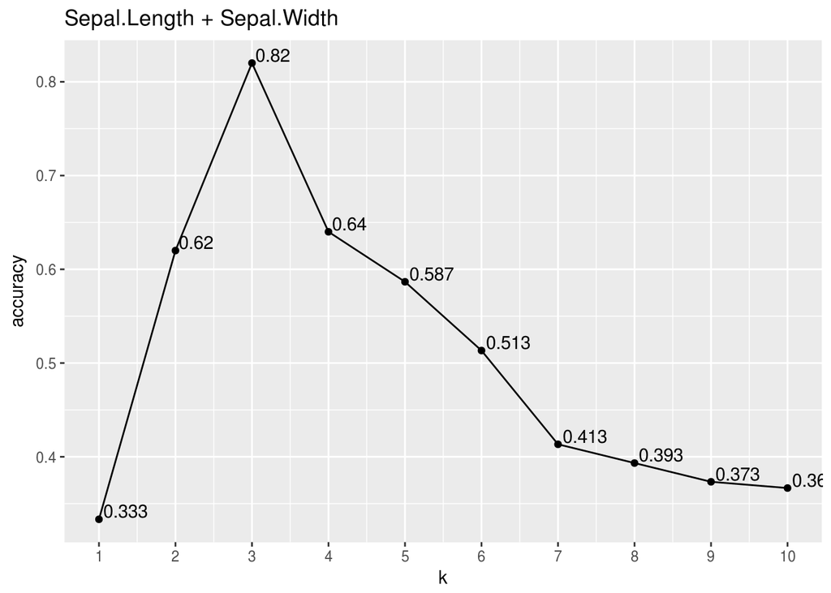

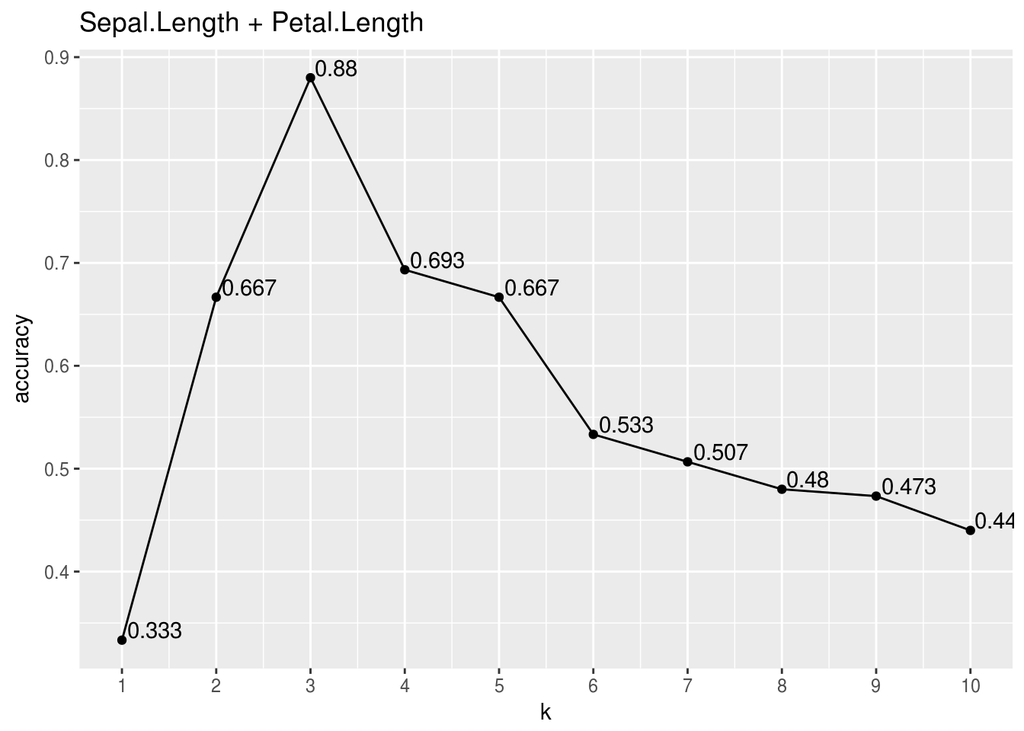

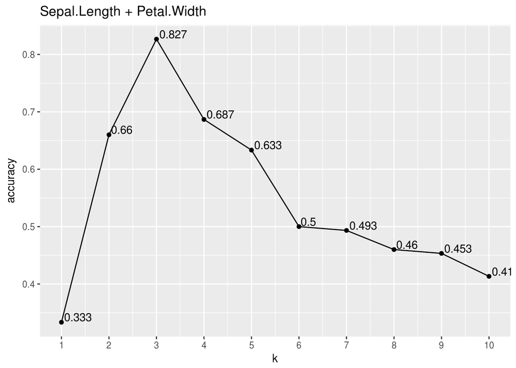

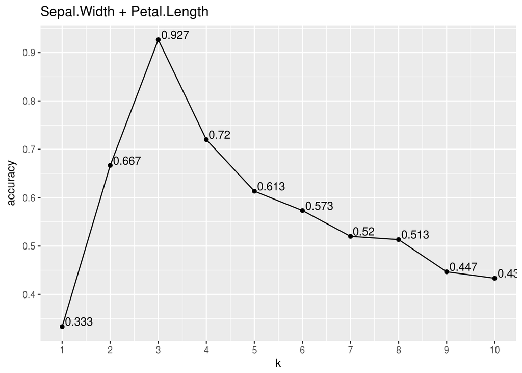

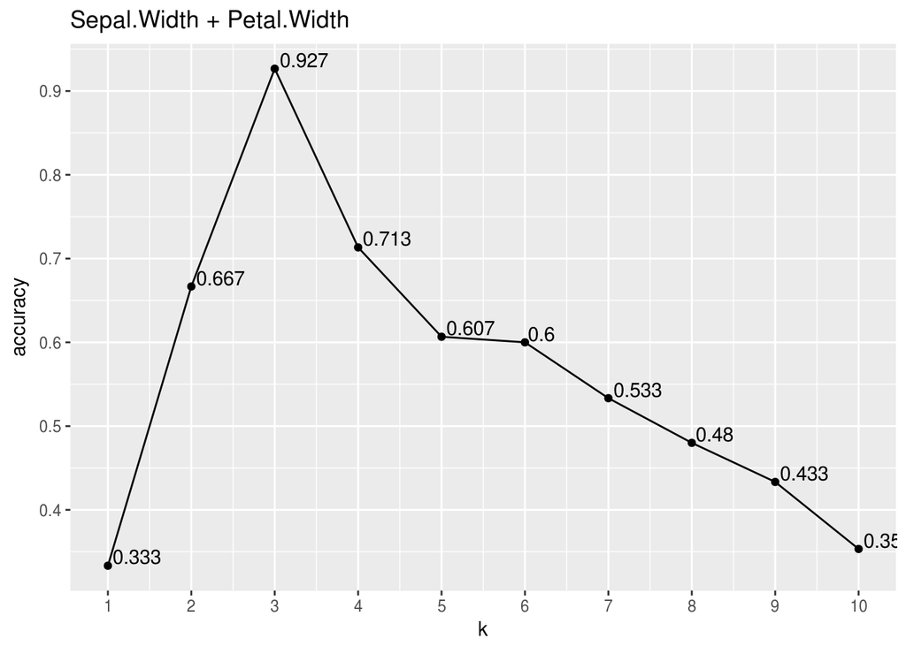

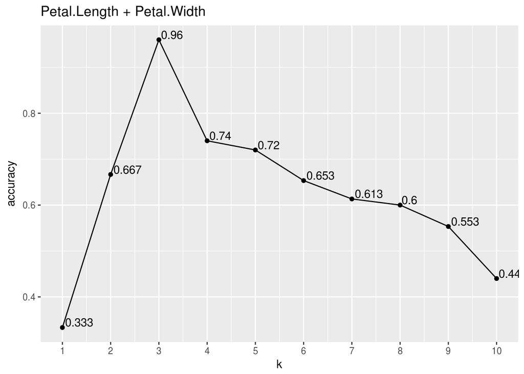

```r
set.seed(66)
combination_2 = combn(c(1:4), 2) # get all combination of two predictors' column index
k =10 # set the k to 10 in k-mean

for (n in 1:ncol(combination_2)){
  iris_predictors = iris[,combination_2[,n]] #get those two specific predictors
  specis = iris[,5] # store the reponses
  accuracy_per_k = c()
  for (i in 1:k){
    k_mean = kmeans(x = as.matrix(iris_predictors), centers = i, nstart = 25)
    # put prediction results from k-mean clustering and actual result side by side
    result = as.data.frame(cbind(prediction = k_mean$cluster, specis))%>%tbl_df()
    # group the data  by both prediction and actual results, and calculate the number of specific
    # species-prediction combinations.
    result_count = group_by(result, specis, prediction)%>%summarise(count = n())
    final_count = list()
    # get the number of correctly clustered data points in each dominate cluster
    for (x in 1:3){
      temp = as.data.frame(result_count[result_count$specis == x,]%>%arrange(desc(count)))
      final_count[[x]] = temp[1,]
     }
    final_count = do.call(rbind, final_count)%>%arrange(desc(count))
    # calculate the accuracy based on different k value
    if (i == 1){
      accuracy = sum(final_count[1, 'count'])/nrow(iris)
      accuracy_per_k = c(accuracy_per_k,accuracy)
    }

    if (i == 2){
      accuracy = sum(final_count[1:2, 'count'])/nrow(iris)
      accuracy_per_k = c(accuracy_per_k,accuracy)
     }

    if (i >= 3){
      accuracy = sum(final_count[1:3, 'count'])/nrow(iris)
      accuracy_per_k = c(accuracy_per_k,accuracy)
    }
  }
  accuracy_per_k = as.data.frame(cbind(k = 1:k, accuracy = accuracy_per_k))
  # graph accuracy vs k
  p = ggplot(accuracy_per_k,aes(x=k,y=accuracy))+geom_point()+geom_line()+scale_x_continuous(breaks=c(1:k))+geom_text(aes(label=round(accuracy,3)),hjust=-0.1, vjust=-0.1)
  p = p + ggtitle(paste(sep = ' + ',
      colnames(iris_predictors)[1],colnames(iris_predictors)[2]))
  print (p)
}
```

It looks like that the combination of **Petal.Length + Petal.Width** yeilds an accuracy of as high as **0.96**.

## 4.2.2 Using **3** predictors for k-mean clustering

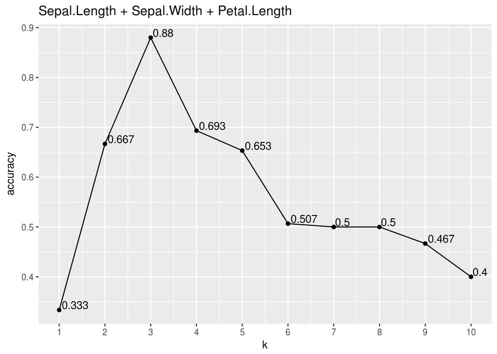

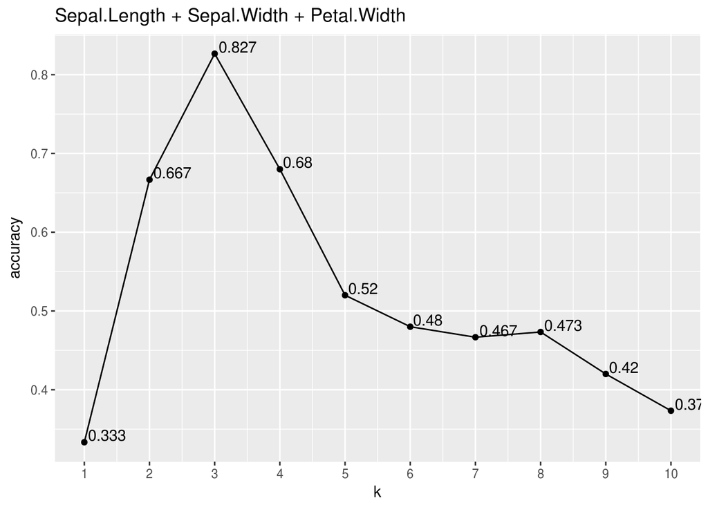

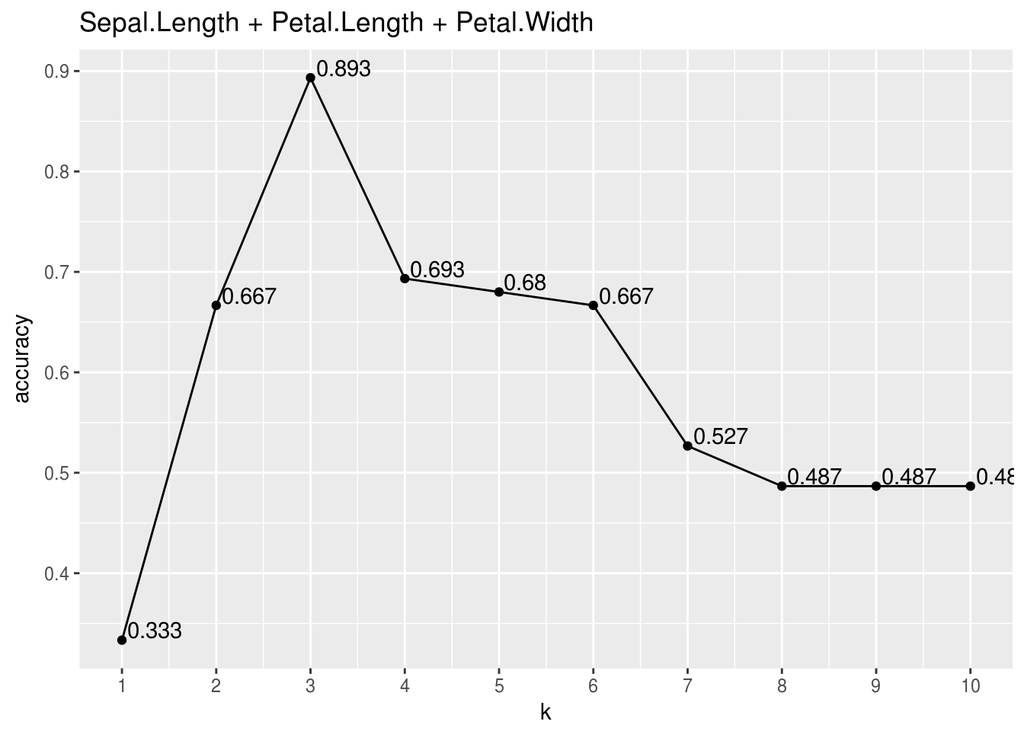

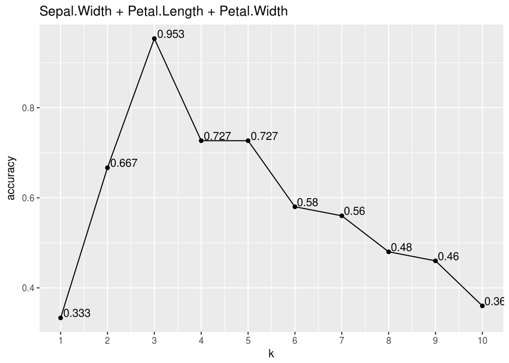

```r
set.seed(66)
combination_3 = combn(c(1:4), 3) # get all combination of three predictors' column index
k =10 # set the k to 10 in k-mean

for (n in 1:ncol(combination_3)){
  iris_predictors = iris[,combination_3[,n]] #get those two specific predictors
  specis = iris[,5] # store the reponses
  accuracy_per_k = c()
  for (i in 1:k){
    k_mean = kmeans(x = as.matrix(iris_predictors), centers = i, nstart = 25)
    # put prediction results from k-mean clustering and actual result side by side
    result = as.data.frame(cbind(prediction = k_mean$cluster, specis))%>%tbl_df()
    # group the data  by both prediction and actual results, and calculate the number of specific
    # species-prediction combinations.
    result_count = group_by(result, specis, prediction)%>%summarise(count = n())
    final_count = list()
    # get the number of correctly clustered data points in each dominate cluster
    for (x in 1:3){
      temp = as.data.frame(result_count[result_count$specis == x,]%>%arrange(desc(count)))
      final_count[[x]] = temp[1,]
     }
    final_count = do.call(rbind, final_count)%>%arrange(desc(count))
    # calculate the accuracy based on different k value
    if (i == 1){
      accuracy = sum(final_count[1, 'count'])/nrow(iris)
      accuracy_per_k = c(accuracy_per_k,accuracy)
    }

    if (i == 2){
      accuracy = sum(final_count[1:2, 'count'])/nrow(iris)
      accuracy_per_k = c(accuracy_per_k,accuracy)
     }

    if (i >= 3){
      accuracy = sum(final_count[1:3, 'count'])/nrow(iris)
      accuracy_per_k = c(accuracy_per_k,accuracy)
    }
  }
  accuracy_per_k = as.data.frame(cbind(k = 1:k, accuracy = accuracy_per_k))
  # graph accuracy vs k
  p = ggplot(accuracy_per_k,aes(x=k,y=accuracy))+geom_point()+geom_line()+scale_x_continuous(breaks=c(1:k))+geom_text(aes(label=round(accuracy,3)),hjust=-0.1, vjust=-0.1)
  p = p + ggtitle(paste(sep = ' + ',
      colnames(iris_predictors)[1],colnames(iris_predictors)[2],colnames(iris_predictors)[3]))
  print (p)
}
```

It looks like that the combination of **Sepal.Width + Petal.Length + Petal.Width** yeilds an accuracy of as high as **0.953**.

## 4.2.3 Using all predictors for k-mean clustering

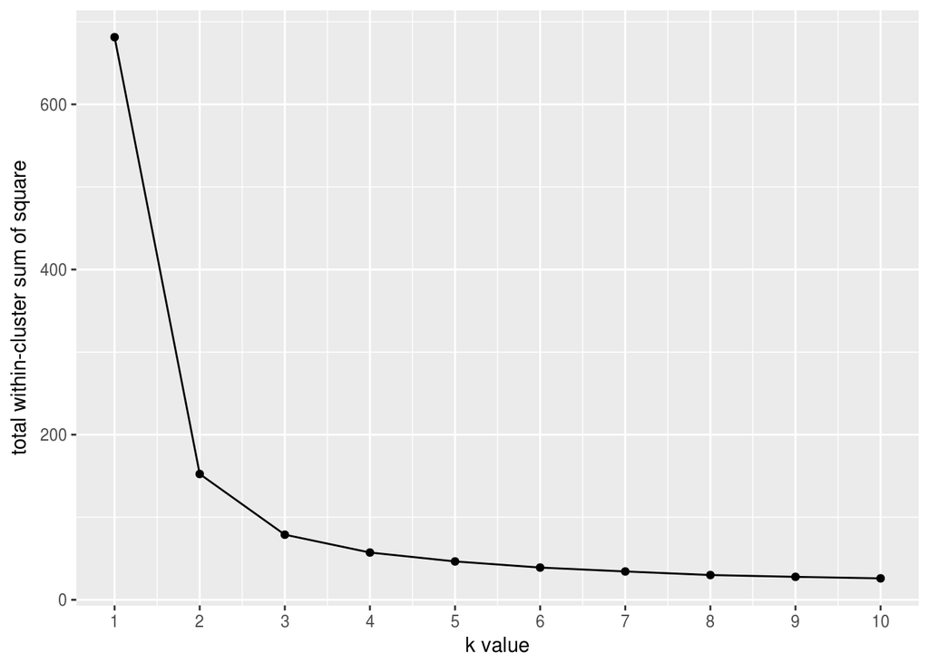

```r
set.seed(66)
data(iris)
iris_predictors = iris[,c(1:4)] # select all predictors
specis = iris[,5] # store the reponses
total_within_cluster_SS = c()
k=10 # try K from 1 to 10
for (i in 1:k){
  k_mean = kmeans(x = as.matrix(iris_predictors), centers = i, nstart = 25)
  # each time, store the total within-cluster sum of square
  total_within_cluster_SS = c(total_within_cluster_SS, k_mean$tot.withinss)
}
total_within_cluster_SS = as.data.frame(cbind('k' = 1:k, 'SS' =total_within_cluster_SS))

#elbow method to assess the quality of k-mean
p = ggplot(data = total_within_cluster_SS, aes(x = k, y = SS))
p = p + geom_point()+geom_line()+labs(y= 'total within-cluster sum of square')+scale_x_continuous(name = 'k value', breaks = total_within_cluster_SS[,1])
p
```

With the help of the elbow graph, it looks like that **k=3** is a good choice.

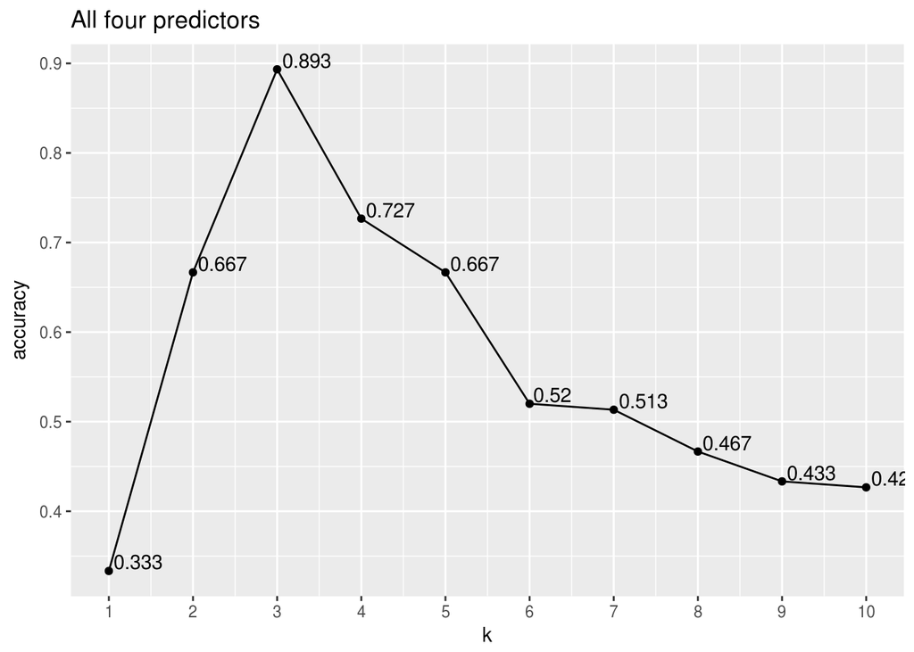

```r
set.seed(66)
accuracy_per_k = c()
for (i in 1:k){
  k_mean = kmeans(x = as.matrix(iris_predictors), centers = i, nstart = 25)
  # put prediction results from k-mean clustering and actual result side by side
  result = as.data.frame(cbind(prediction = k_mean$cluster, specis))%>%tbl_df()
  # group the data  by both prediction and actual results, and calculate the number of specific
  # species-prediction combinations.
  result_count = group_by(result, specis, prediction)%>%summarise(count = n())
  final_count = list()
  # get the number of correctly clustered data points in each dominate cluster
  for (x in 1:3){
    temp = as.data.frame(result_count[result_count$specis == x,]%>%arrange(desc(count)))
    final_count[[x]] = temp[1,]
    }
  final_count = do.call(rbind, final_count)%>%arrange(desc(count))
  # calculate the accuracy based on different k value
  if (i == 1){
    accuracy = sum(final_count[1, 'count'])/nrow(iris)
    accuracy_per_k = c(accuracy_per_k,accuracy)
  }

  if (i == 2){
    accuracy = sum(final_count[1:2, 'count'])/nrow(iris)
    accuracy_per_k = c(accuracy_per_k,accuracy)
    }

  if (i >= 3){
    accuracy = sum(final_count[1:3, 'count'])/nrow(iris)
    accuracy_per_k = c(accuracy_per_k,accuracy)
  }
}
accuracy_per_k = as.data.frame(cbind(k = 1:k, accuracy = accuracy_per_k))

# graph accuracy vs k
p = ggplot(accuracy_per_k,aes(x=k,y=accuracy))+geom_point()+geom_line()+scale_x_continuous(breaks=c(1:k))+geom_text(aes(label=round(accuracy,3)),hjust=-0.1, vjust=-0.1)
p = p+ggtitle('All four predictors')
print (p)
```

By using all four predictors, I got an prediction accuracy of **0.893**.

### Thus the best prediction accuracy is from the combination of **Petal.Length + Petal.Width** when k is set to **3**.

Then I try to visulize the prediction rsult vs the actual cluster by using ggplot.

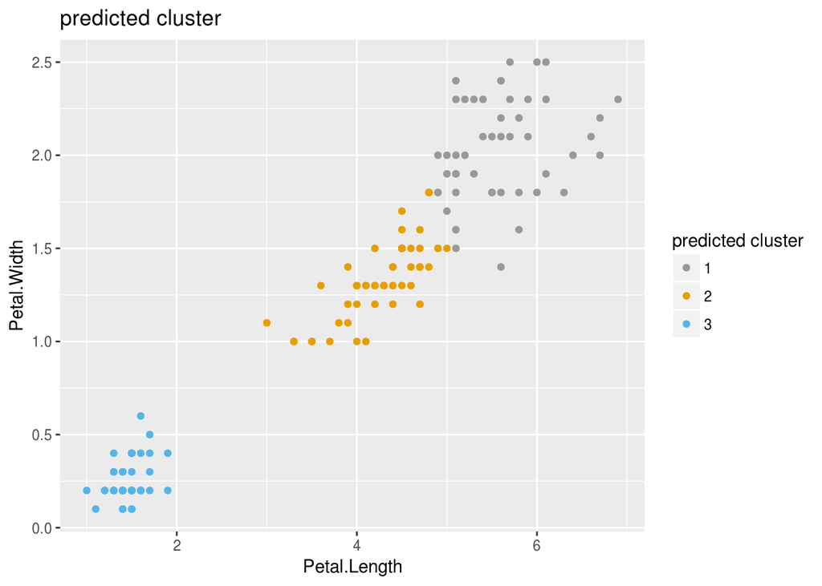

```r
set.seed(66)
iris_predictors = iris[,3:4]
k_mean = kmeans(iris_predictors, centers = 3, nstart = 25)
prediction = k_mean$cluster
iris_with_prediction = cbind(iris, prediction)
p = ggplot(data = iris_with_prediction,
           aes(x = Petal.Length, y = Petal.Width, color = as.factor(prediction))
)
p = p + geom_point()+labs(color="predicted cluster")+ggtitle('predicted cluster')
p = p + scale_color_manual(values=c("#999999", "#E69F00", "#56B4E9"))
p
```

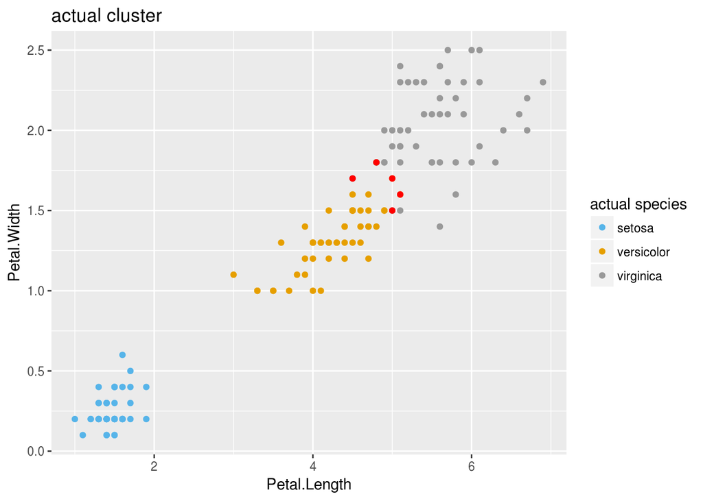

```r
p = ggplot(data = iris,
           aes(x = Petal.Length, y = Petal.Width, color = as.factor(specis)))
p = p + geom_point()+labs(color="actual species")+ggtitle('actual cluster')
p = p + geom_point(data = iris[c(78,84,107,120,127),], aes(x = Petal.Length, y = Petal.Width), color ='red')
p = p + scale_color_manual(values=c("#56B4E9", "#E69F00" ,"#999999"))
p
```

# Conslusion

#### The best combination of predictors : **Petal.Length + Petal.Width**

#### Suggested value of k: **3**

#### Accuracy based on k-mean method: **0.96**